# Семинары 12-13. Разрывная регрессия

Анна Ставнийчук

21-28 ноября 2022

annastavnychuk@gmail.com

# 1. Четкая разрывная регрессия

В нашей жизни есть много правил. Очень часто эти правила регламентированы какими-то критериями. Например, чтобы поступить в университет, нужно набрать определенное количество баллов, чтобы понести наказание за вождение в нетрезвом виде, в крови должно быть обнаружено более определенного числа промилле алкоголя, чтобы получить отличную оценку, нужно набрать критерий по теории на экзамене и так далее… Иными словами мы в своем изучении эконометрических методов столнулись с ситуацией, когда наш тритмент не просто эндогенный, он еще и может зависеть от какой-то другой континуальной переменной. Для того, чтобы решать такие задачи, был придуман дизайн разрывной регрессии.

Базовая постановка выглядит следующим образом:

- $Y_0, Y_1$ – потенциальные исходы
- $T$ – тритмент переменная
- $R$ – переменная, по которой есть критерий попадания в тритмент (running variable, “бегущая перменная”)
- $X$ – прочие контрольные переменные

Тритмент переменная $T$ является функцией от $R$, такой что $T = \mathbb{I}(R>c)$, где $\mathbb{I}(.)$ индикаторная функция, принимающее значение 1, если выражение в скабках истинно, а $c$ – некоторая отсечка (cutoff), после достижения которой наблюдение попадает в группу воздействия. То же самое можно записать в виде системы:

$$T(R)=
\begin{cases}
1, R>c\\
0, R<c\\
\end{cases}$$

На рисунках ниже изображена вероятность попадания в тритмент группу. По оси абсцисс – бегущая переменная, по оси ординат – вероятность попадания в тритмент. В данном примере $c=6$.

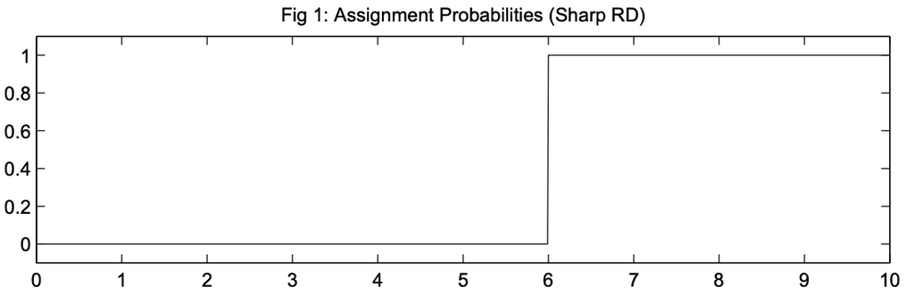

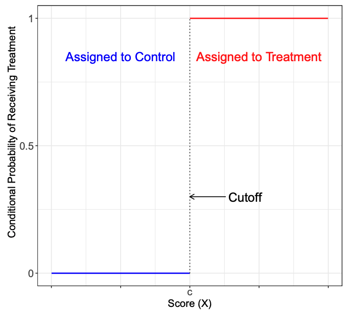

Далее обратимся к потенциальным исходам, которые обозначены ниже пунктирными линиями. Видим, что левее от отсечки по бегущей переменной реализуется $Y_0$, правее – $Y_1$. Таким образом, наблюдаемый $Y$ обозначен сплошной линией. Математически это как и раньше описывается формулой $Y = T\cdot Y_1 + (1-T)\cdot Y_0$

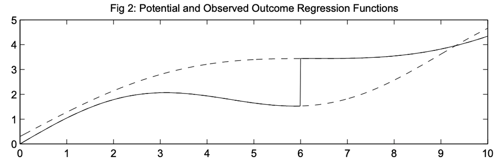

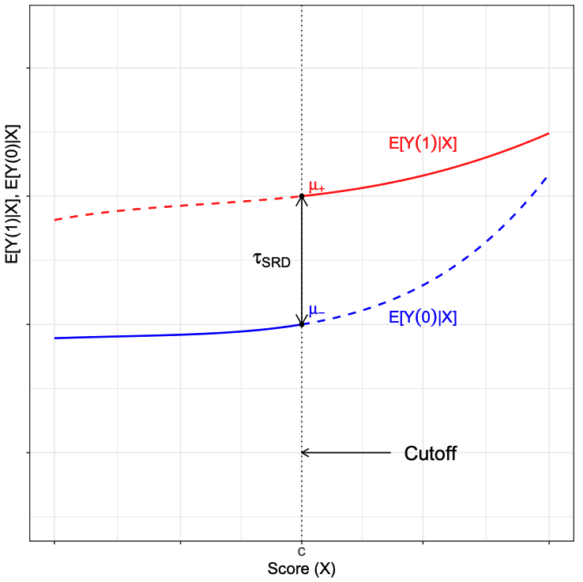

Вернемся к формальному описанию предпосылок.

- предпосылка об экзогенности $(Y_0, Y_1, R) \perp T$ не просто нарушена, назначение $T$ в нашем случае вообще является правилом $T(R)$
- предпосылка о несмешиваемости (unconfoundedness) $(Y_0, Y_1) \perp T | R$ выполнена
- предпосылка о перекрытии (overlap) $1>P(T|R)>0$ нарушена

Заметим, что в такой ситуации мы не можем использовать другие методы, например, мэтчинг. Почему? Как раз из-за нарушения последней предпосылки, у нас просто нет для этого контрольной группы.

Вместо предпосылки об экзогенности тритмента выше предположим непрерывность функций $E(Y_1|R), E(Y_0|R), E(X|R)$. Можем ли мы как-то проверить этот факт? Для потенциальных исходов, конечно, нет, мы их вовсе не наблюдаем. В непрерывность $Y$ мы, увы просто верим и можем обосновывать её содержательными соображениями, а вот непрерывность $X$ мы вполне можем проверить. Например, мы можем нарисовать график зависимости $X$ от running variable. Таким образом, мы можем обоснованно заявлять, что разрыв в $Y$ вызван изучаемым эффектом, а не каким-либо структурным сдвигом в $X$.

Отдельно, как ниже, стоит проверить распределение количества людей относительно отсечки, чтобы обезопасить себя от проблемы самоотбора, как на картинке справа:

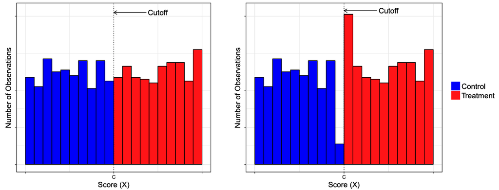

Далее перейдём к оценке. Как мы говорили ранее, самая сложная проблема, которая перед нами стоит – это то, что у нас нет контрольной группы. Сравнить среднее значение зависимой переменной слева от отсечки со средним значением справа будет являться плохой оценкой, потому что наблюдения будут несопоставимы и полученная разница может объясняться различиями к контрольных переменных, а не тем эффектом, который мы хотим оценить.

Эконометристы придумали следующий финт – если мы возьмём наблюдения, которые расположены достаточно близко к отсечке, то они будут похожи друг на друга по величине running variable. Промежуток по running variable, который мы выбираем вокруг отсечки называется окном, размер этого промежутка – шириной окна (bandwidth). Если мы выберем маленькое окно, то получим что-то вроде локальной рандомизации, где наша оценка будет равна обычной разнице в средних.

$$\tau_{SRD} = \underset{R \rightarrow
c+}{lim} E [Y|R] - \underset{R \rightarrow c-}{lim} E [Y|R]$$

$$\hat{\tau}_{SRD} = \left.\overline{Y}
\right|_{c<R<c+h}-\left.\overline{Y}
\right|_{c-h<R<c}$$

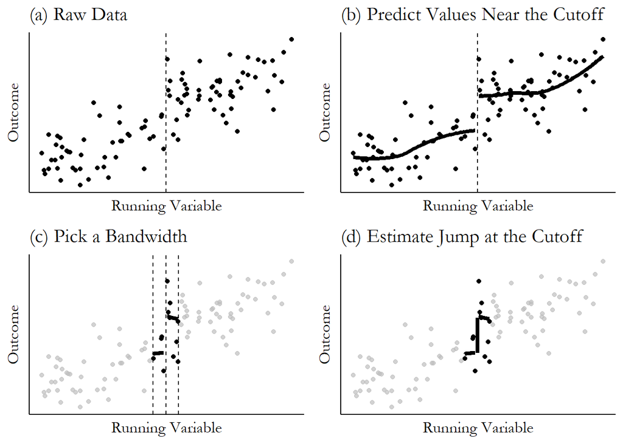

Итак, подведем итог, чтобы оценить эффект, нам сначала нужно выбрать шиину окна (обозначим её $h$). Затем на данных, которые лежат в пределах нашего окна $R \in [c-h;c+h]$ считаем оценку $\displaystyle{LATE = E(\tau|R=c) = \hat{\tau}_{SRD} = \frac{\sum \limits_{c<R<c+h} Y_i}{\sum (c<R<c+h)} - \frac{\sum \limits_{c-h<R<c} Y_i}{\sum (c-h<R<c)}}$, как и раньше это эквивалентно регресии $\displaystyle{Y = \beta_1 + \tau \cdot T}$. Добавлять контрольные переменные можно, это позволит дополнительно снизить дисперсию оценки. Иногда еще добавляют контроль на тренд $\displaystyle{Y = \beta_1 + \tau \cdot T + \beta_2 \cdot R + \beta_3 \cdot T \cdot R}$.

Важно отметить, что чем более широкое окно мы возьмём, тем больше наблюдений мы захватим и тем более точную оценку с меньшей дисперисей мы получим (и с более узким доверительным интервалом, что хорошо!), однако если взять слишком широкое окно, то это чревато тем, что мы захватим слишком непохожие друг на друга наблюдения и наша оценка получится смещенной. Верно и обратно, чем меньше окно, тем меньше вероятность нарваться на смещение, однако дисперсия оценки (и доверительный интервал) с маленьким окном будет выше:

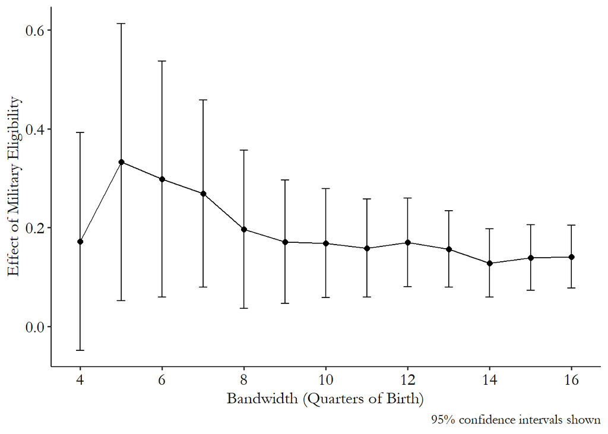

Существует некоторое дополнение метода, связанное с перевзвешиванием данных. Мы предположили, что наблюдения, которые находятся внутри выбранного нами окна, достаточно похожи друг на друга, чтобы мы могли их сравнивать. Однако чем ближе наблюдения к отсечке, тем больше они похожи друг на друга. Может стоит придавать им больший вес? Для этого были придуманы оценки с помощью ядер (по сути взвешенный МНК). Некоторые из них нарисованы на рисунке ниже.

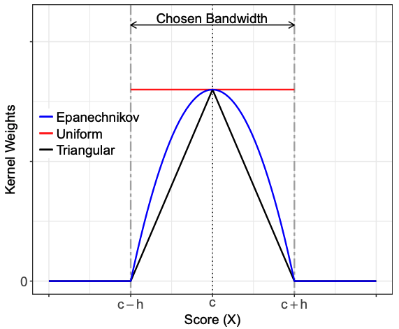

Тогда задача МНК примет вид:

$$\hat{\mathbb{\beta}} =
\underset{\beta_0, \beta_1, \beta_2, \tau}{\operatorname{argmin}} ESS =
\underset{\beta_0, \beta_1, \beta_2, \tau}{\operatorname{argmin}}
\sum_{i=1}^n\left[\left(y_i-\hat{\beta}_0-\hat{\beta}_1 R_i-\hat{\tau}
T_i-\beta_2 T_i R_i\right)^2\right. \cdot
\left.K\left(\frac{R_i-c}{h}\right)\right]$$

где $K(.)$ – функция плотности ядерной оценки.

Например, если мы хотим для всех наблюдений использовать одинаковые веса, то мы используем равномерное распределение, функция плотности которого равна:

$$K\left(\frac{R_i-c}{h}\right)=\left\{\begin{array}{l}
\frac{1}{2 h}, \text{внутри окна} \\
0, \text{вне окна}
\end{array}\right.$$

# 2. Пример четкой разрывной регрессии

Одним из вопросов государственной политики является вопрос о том, каким должен быть минимальный возраст, с которого разрешается продавать алкоголь.В большинстве стран этот возраст установлен на уровне 18 лет, но в США (в большинстве штатов) в настоящее время он составляет 21 год.

Проявляют ли США чрезмерную осторожность? Можно ли снизить допустимый возраст до 18 лет? Или это тот случай, когда другие страны должны повысить границу минимального возраста употребления алкоголя?

Один из способов ответить на этот вопрос – оценить ситуацию с точки зрения уровня смертности (Carpenter and Dobkin, 2009). С точки зрения государственной политики можно утверждать, что мы должны максимально снизить уровень смертности. Если потребление алкоголя значительно увеличивает смертность, нам следует избегать снижения минимального возраста употребления алкоголя.

Чтобы оценить влияние алкоголя на смертность, мы могли бы использовать тот факт, что возраст, в котором разрешено употребление алкоголя, создает разрыв. В США люди младше 21 года не пьют (или пьют гораздо меньше), а те, кому чуть больше 21 года, пьют. Это означает, что вероятность пьянства резко возрастает в возрасте 21 года, и это то, что мы можем исследовать с помощью RDD.

Для начала импортируем данные из статьи (Carpenter and Dobkin, 2009):

```r
library(foreign)
data <- read.dta("Seminar_12-13_regression_discontinuity_data/AEJfigs.dta")
```

Имеем следующие переменные:

- agecell – возраст
- количество смертей на 100 000 людей в данной возрастной группе
  - all – общее количество смертей
  - internal – смерти от внутренних причин (состояние здоровья и т.д.)
  - external – смерти от внешних причин (связанные с воздействием окружающей среды, разные травмы и т.д.), в том числе:
    - alcohol – смерти, вызванные алкоголем
    - homicide – смерти, связанные с убийствами
    - suicide – самоубийства
    - mva – смерти, вызванные ДТП
    - drugs – смерти, вызванные наркотиками
    - externalother – другие внешние причины

```r
library(stargazer)
stargazer(data, type = "text")
```

```
##
## =====================================================
## Statistic           N   Mean  St. Dev.  Min     Max
## -----------------------------------------------------
## agecell             50 21.000  1.127   19.068 22.932
## all                 48 95.673  3.831   88.428 105.268
## allfitted           50 95.803  3.286   91.706 102.892
## internal            48 20.285  2.254   15.977 24.373
## internalfitted      50 20.281  1.995   16.738 24.044
## external            48 75.387  2.986   71.341 83.331
## externalfitted      50 75.522  2.270   73.158 81.784
## alcohol             48 1.257   0.350   0.639   2.519
## alcoholfitted       50 1.267   0.260   0.794   1.817
## homicide            48 16.912  0.730   14.948 18.411
## homicidefitted      50 16.953  0.453   16.261 17.762
## suicide             48 12.352  1.063   10.889 14.832
## suicidefitted       50 12.363  0.760   11.592 13.547
## mva                 48 31.623  2.385   26.855 36.385
## mvafitted           50 31.680  2.003   27.868 34.818
## drugs               48 4.250   0.616   3.202   5.565
## drugsfitted         50 4.255   0.521   3.449   5.130
## externalother       48 9.599   0.748   7.973  11.483
## externalotherfitted 50 9.610   0.465   8.388  10.353
## -----------------------------------------------------
```

### 2.1. Подготовка данных

Сначала оценим эффект вручную с помощью МНК без использования ядер, затем воспользуемся специальным пакетом.

Для этого создадим тритмент переменную на основе отсечки и переменную квадрата возраста (наверняка вы уже встречались с примерами, когда зависимость от возраста бывает квадратичной, то есть существует какой-то минимальный или максимальный возраст в зависимости $Y$ от $X$):

```r
data$T <- data$agecell>=21
data$age2 <- data$agecell^2
```

Далее нам нужно ограничить данные окном. Предположительно выберем окно шириной в один год. Далее пакет нам посчитает оптимальную ширину окна, а пока сделаем пробный вариант. Для этого отфильтруем наши данные по окну:

```r
library(dplyr)
data_h <- data %>% filter(agecell>20 & agecell<22)
```

### 2.2. Вручную с помощью регрессии

#### 2.2.1. Оценка разрыва в общей смертности

Теперь непосредственно регрессия:

```r
mod_ols <- lm(all ~ agecell + T, data = data_h)
summary(mod_ols)
```

```
##
## Call:
## lm(formula = all ~ agecell + T, data = data_h)
##
## Residuals:
##     Min      1Q  Median      3Q     Max
## -4.2577 -1.1736  0.0033  1.2509  3.9358
##
## Coefficients:
##             Estimate Std. Error t value Pr(>|t|)
## (Intercept)  160.094     34.860   4.592 0.000158 ***
## agecell       -3.256      1.700  -1.916 0.069094 .
## TTRUE          9.753      1.934   5.043 5.41e-05 ***
## ---
## Signif. codes:  0 '***' 0.001 '**' 0.01 '*' 0.05 '.' 0.1 ' ' 1
##
## Residual standard error: 2.362 on 21 degrees of freedom
##   (2 пропущенных наблюдений удалены)
## Multiple R-squared:  0.7029, Adjusted R-squared:  0.6746
## F-statistic: 24.84 on 2 and 21 DF,  p-value: 2.924e-06
```

Получили, что смертность людей старше 21 года на 9.8 выше, чем среди людей моложе 21.

Тот же результат, но графически:

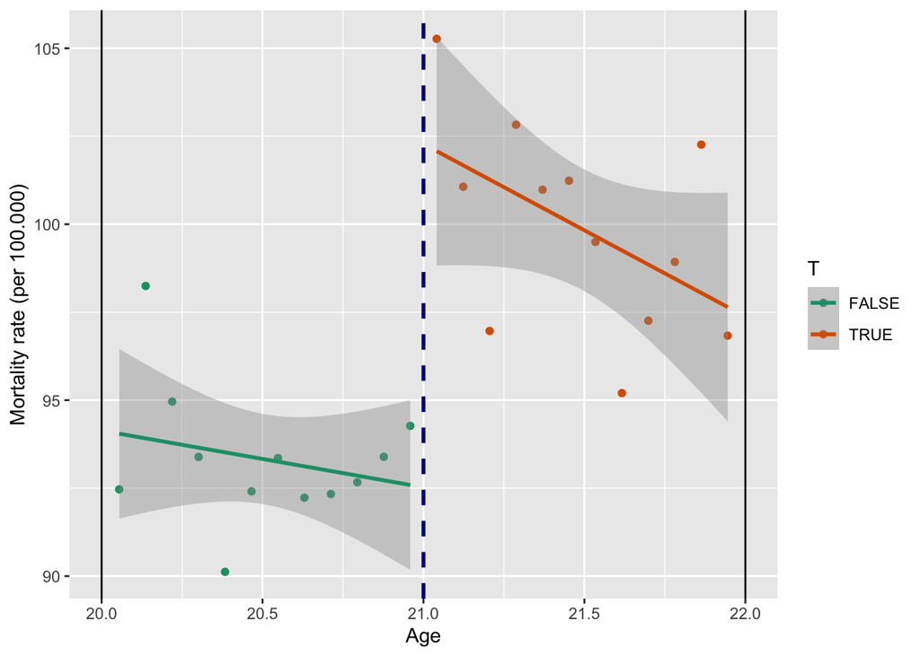

```r
library(ggplot2)

ggplot(data_h, aes(x = agecell, y = all, color = T)) +
geom_point() +
geom_smooth(method = "lm") +
scale_color_brewer(palette = "Dark2") +
geom_vline(xintercept = 21, color = "darkblue", size = 1, linetype = "dashed") +
geom_vline(xintercept = 20) +
geom_vline(xintercept = 22) +
labs(y = "Mortality rate (per 100.000)",
     x = "Age")
```

Посмотрим то же самое, но теперь еще добавим квадрат возраста:

```r
mod_ols2<-lm(all ~ agecell + age2 + T, data = data_h)
summary(mod_ols2)
```

```
##
## Call:
## lm(formula = all ~ agecell + age2 + T, data = data_h)
##
## Residuals:
##     Min      1Q  Median      3Q     Max
## -4.2063 -1.0465 -0.1178  1.0289  4.1069
##
## Coefficients:
##              Estimate Std. Error t value Pr(>|t|)
## (Intercept) -242.2799   749.5323  -0.323    0.750
## agecell       35.0933    71.3774   0.492    0.628
## age2          -0.9131     1.6990  -0.537    0.597
## TTRUE          9.7533     1.9676   4.957 7.59e-05 ***
## ---
## Signif. codes:  0 '***' 0.001 '**' 0.01 '*' 0.05 '.' 0.1 ' ' 1
##
## Residual standard error: 2.403 on 20 degrees of freedom
##   (2 пропущенных наблюдений удалены)
## Multiple R-squared:  0.7071, Adjusted R-squared:  0.6632
## F-statistic: 16.09 on 3 and 20 DF,  p-value: 1.473e-05
```

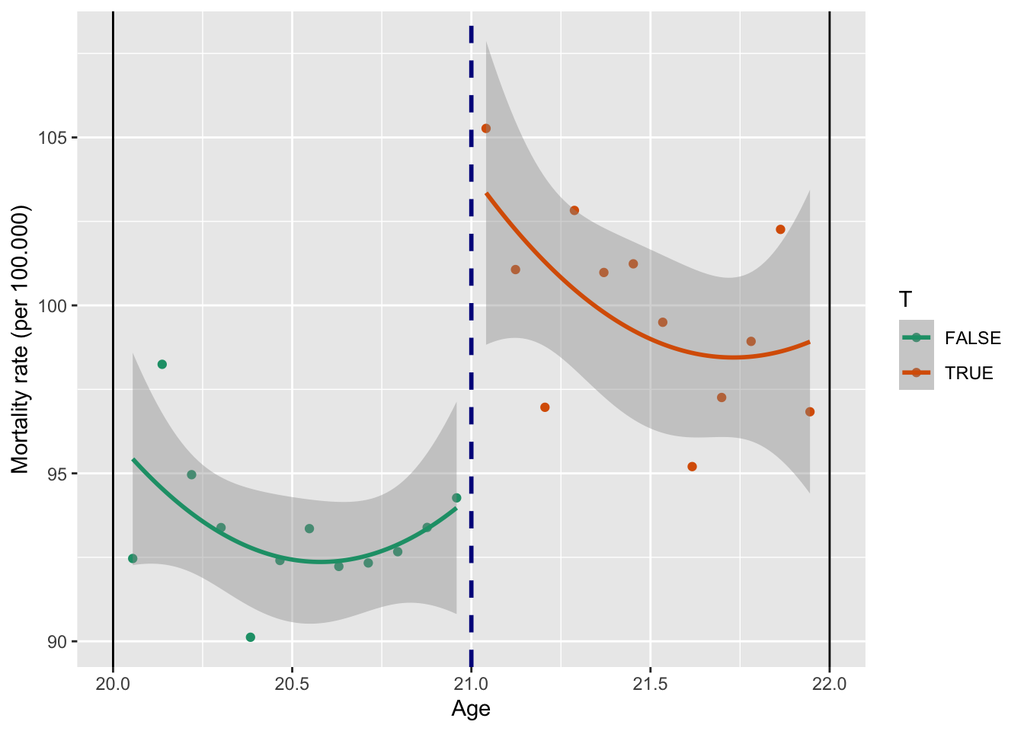

```r
ggplot(data_h, aes(x = agecell, y = all, color = T)) +
geom_point() +
geom_smooth(method = "lm",
            formula = y ~ x + I(x ^ 2)) +
scale_color_brewer(palette = "Dark2") +
geom_vline(xintercept = 21, color = "darkblue", size = 1, linetype = "dashed") +
geom_vline(xintercept = 20) +
geom_vline(xintercept = 22) +
labs(y = "Mortality rate (per 100.000)",
     x = "Age")
```

Мы поняли, что разрыв точно есть и он значим. Поробуем разобраться за счет каких причин он происходит.

#### 2.2.2. Разбивка на внутренние и внешние причины

##### 2.2.2.1. Внутренние

```r
mod_internal<-lm(internal ~ agecell + T, data = data_h)
summary(mod_internal)
```

```
##
## Call:
## lm(formula = internal ~ agecell + T, data = data_h)
##
## Residuals:
##      Min       1Q   Median       3Q      Max
## -1.92574 -0.62316  0.07478  0.72291  1.38703
##
## Coefficients:
##              Estimate Std. Error t value Pr(>|t|)
## (Intercept) 19.686485  13.438734   1.465   0.1578
## agecell     -0.009418   0.655204  -0.014   0.9887
## TTRUE        1.692263   0.745552   2.270   0.0339 *
## ---
## Signif. codes:  0 '***' 0.001 '**' 0.01 '*' 0.05 '.' 0.1 ' ' 1
##
## Residual standard error: 0.9107 on 21 degrees of freedom
##   (2 пропущенных наблюдений удалены)
## Multiple R-squared:  0.4938, Adjusted R-squared:  0.4456
## F-statistic: 10.24 on 2 and 21 DF,  p-value: 0.0007851
```

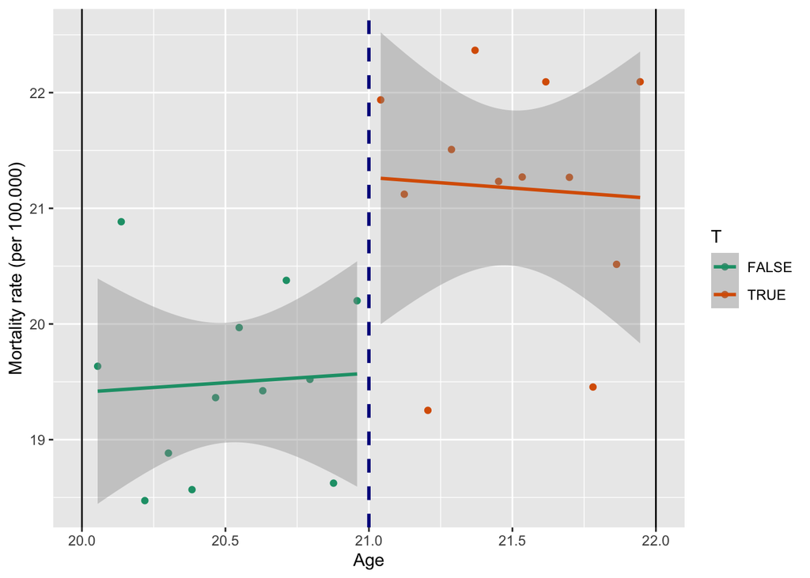

```r
ggplot(data_h, aes(x = agecell, y = internal, color = T)) +
geom_point() +
geom_smooth(method = "lm") +
scale_color_brewer(palette = "Dark2") +
geom_vline(xintercept = 21, color = "darkblue", size = 1, linetype = "dashed") +
geom_vline(xintercept = 20) +
geom_vline(xintercept = 22) +
labs(y = "Mortality rate (per 100.000)",
     x = "Age")
```

Разыв маленький (гораздо меньше общего) и значим только на 5% уровне.

##### 2.2.2.2. Внешние

```r
mod_external <- lm(external ~ agecell + T, data = data_h)
summary(mod_external)
```

```
##
## Call:
## lm(formula = external ~ agecell + T, data = data_h)
##
## Residuals:
##     Min      1Q  Median      3Q     Max
## -5.1759 -1.3786 -0.1486  1.7247  4.2633
##
## Coefficients:
##             Estimate Std. Error t value Pr(>|t|)
## (Intercept)  140.408     33.698   4.167 0.000436 ***
## agecell       -3.247      1.643  -1.976 0.061409 .
## TTRUE          8.061      1.869   4.312 0.000308 ***
## ---
## Signif. codes:  0 '***' 0.001 '**' 0.01 '*' 0.05 '.' 0.1 ' ' 1
##
## Residual standard error: 2.284 on 21 degrees of freedom
##   (2 пропущенных наблюдений удалены)
## Multiple R-squared:  0.5967, Adjusted R-squared:  0.5582
## F-statistic: 15.53 on 2 and 21 DF,  p-value: 7.236e-05
```

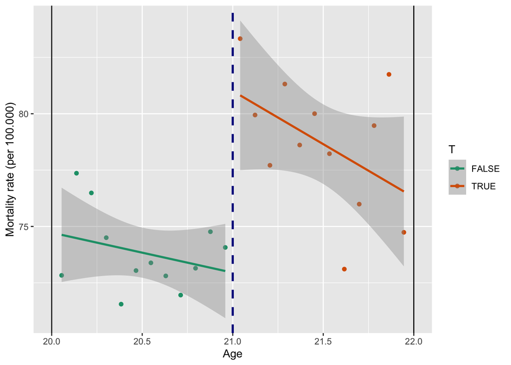

```r
ggplot(data_h, aes(x = agecell, y = external, color = T)) +
geom_point() +
geom_smooth(method = "lm") +
scale_color_brewer(palette = "Dark2") +
geom_vline(xintercept = 21, color = "darkblue", size = 1, linetype = "dashed") +
geom_vline(xintercept = 20) +
geom_vline(xintercept = 22) +
labs(y = "Mortality rate (per 100.000)",
     x = "Age")
```

Видим, что общая смертность преимущественно объясняется разрывом в смертности от внешних причин, то есть гипотеза про последствия от снижения минимального возраста продажи алкоголя пока не отвергается. Рассмотрим за счет каких причин возникает разрыв в смертности от внешних причин.

###### Алкоголь

```r
mod_alcohol <- lm(alcohol ~ agecell + T, data = data_h)
summary(mod_alcohol)
```

```
##
## Call:
## lm(formula = alcohol ~ agecell + T, data = data_h)
##
## Residuals:
##     Min      1Q  Median      3Q     Max
## -0.4320 -0.1958 -0.0712  0.1912  0.8790
##
## Coefficients:
##             Estimate Std. Error t value Pr(>|t|)
## (Intercept)   7.7760     4.2741   1.819  0.08315 .
## agecell      -0.3268     0.2084  -1.568  0.13177
## TTRUE         0.7405     0.2371   3.123  0.00515 **
## ---
## Signif. codes:  0 '***' 0.001 '**' 0.01 '*' 0.05 '.' 0.1 ' ' 1
##
## Residual standard error: 0.2897 on 21 degrees of freedom
##   (2 пропущенных наблюдений удалены)
## Multiple R-squared:  0.4161, Adjusted R-squared:  0.3605
## F-statistic: 7.481 on 2 and 21 DF,  p-value: 0.003522
```

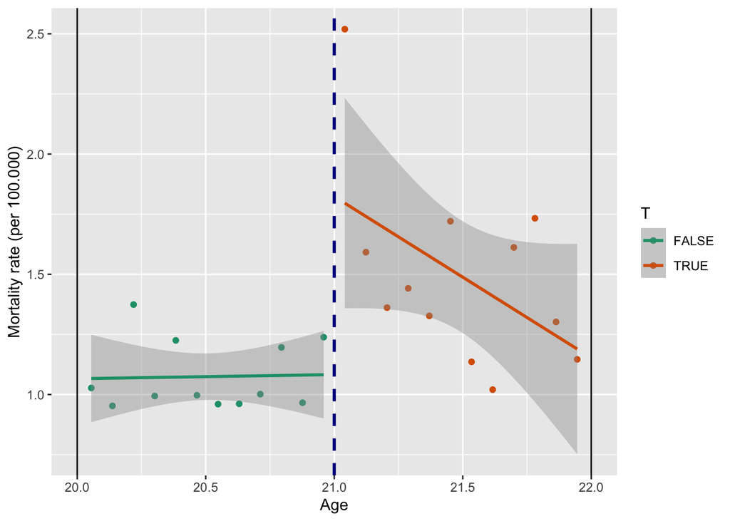

```r
ggplot(data_h, aes(x = agecell, y = alcohol, color = T)) +
geom_point() +
geom_smooth(method = "lm") +
scale_color_brewer(palette = "Dark2") +
geom_vline(xintercept = 21, color = "darkblue", size = 1, linetype = "dashed") +
geom_vline(xintercept = 20) +
geom_vline(xintercept = 22) +
labs(y = "Mortality rate (per 100.000)",
     x = "Age")
```

###### Убийства

```r
mod_homicide <- lm(homicide ~ agecell + T, data = data_h)
summary(mod_homicide)
```

```
##
## Call:
## lm(formula = homicide ~ agecell + T, data = data_h)
##
## Residuals:
##      Min       1Q   Median       3Q      Max
## -1.13706 -0.35555  0.03508  0.35236  1.08442
##
## Coefficients:
##             Estimate Std. Error t value Pr(>|t|)
## (Intercept)  12.4593     9.8133   1.270    0.218
## agecell       0.2211     0.4784   0.462    0.649
## TTRUE         0.1638     0.5444   0.301    0.766
##
## Residual standard error: 0.665 on 21 degrees of freedom
##   (2 пропущенных наблюдений удалены)
## Multiple R-squared:  0.09453,    Adjusted R-squared:  0.008298
## F-statistic: 1.096 on 2 and 21 DF,  p-value: 0.3525
```

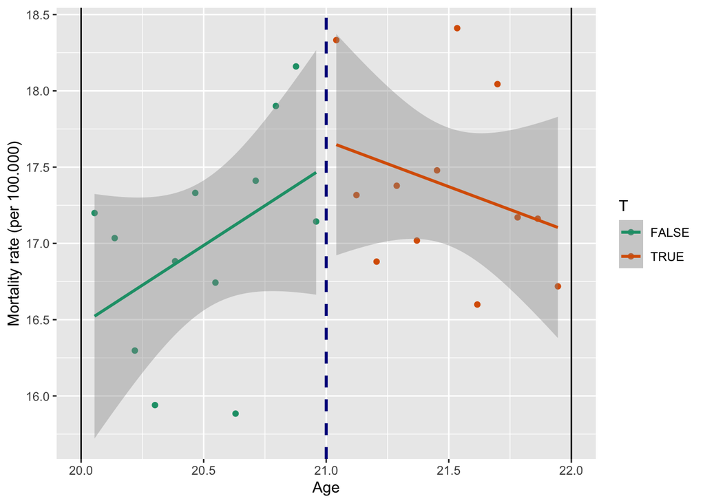

```r
ggplot(data_h, aes(x = agecell, y = homicide, color = T)) +
geom_point() +
geom_smooth(method = "lm") +
scale_color_brewer(palette = "Dark2") +
geom_vline(xintercept = 21, color = "darkblue", size = 1, linetype = "dashed") +
geom_vline(xintercept = 20) +
geom_vline(xintercept = 22) +
labs(y = "Mortality rate (per 100.000)",
     x = "Age")
```

###### Самоубийства

```r
mod_suicide <- lm(suicide ~ agecell + T, data = data_h)
summary(mod_suicide)
```

```
##
## Call:
## lm(formula = suicide ~ agecell + T, data = data_h)
##
## Residuals:
##      Min       1Q   Median       3Q      Max
## -1.54946 -0.57179  0.09345  0.56743  1.46789
##
## Coefficients:
##              Estimate Std. Error t value Pr(>|t|)
## (Intercept) 11.754110  12.491886   0.941   0.3574
## agecell     -0.005422   0.609040  -0.009   0.9930
## TTRUE        1.724426   0.693023   2.488   0.0213 *
## ---
## Signif. codes:  0 '***' 0.001 '**' 0.01 '*' 0.05 '.' 0.1 ' ' 1
##
## Residual standard error: 0.8466 on 21 degrees of freedom
##   (2 пропущенных наблюдений удалены)
## Multiple R-squared:  0.5409, Adjusted R-squared:  0.4972
## F-statistic: 12.37 on 2 and 21 DF,  p-value: 0.0002819
```

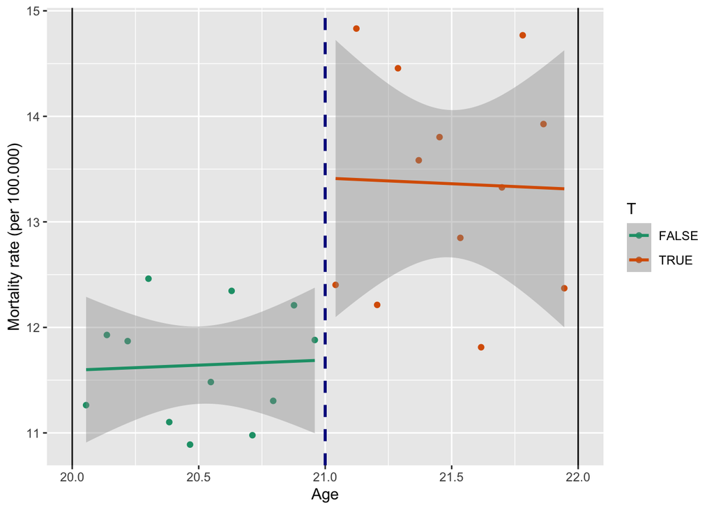

```r
ggplot(data_h, aes(x = agecell, y = suicide, color = T)) +
geom_point() +
geom_smooth(method = "lm") +
scale_color_brewer(palette = "Dark2") +
geom_vline(xintercept = 21, color = "darkblue", size = 1, linetype = "dashed") +
geom_vline(xintercept = 20) +
geom_vline(xintercept = 22) +
labs(y = "Mortality rate (per 100.000)",
     x = "Age")
```

###### ДТП

```r
mod_mva <- lm(mva ~ agecell + T, data = data_h)
summary(mod_mva)
```

```
##
## Call:
## lm(formula = mva ~ agecell + T, data = data_h)
##
## Residuals:
##     Min      1Q  Median      3Q     Max
## -2.1088 -0.8810 -0.3918  0.7157  3.1297
##
## Coefficients:
##             Estimate Std. Error t value Pr(>|t|)
## (Intercept) 102.4206    19.7941   5.174 3.98e-05 ***
## agecell      -3.4683     0.9651  -3.594 0.001708 **
## TTRUE         4.7593     1.0981   4.334 0.000292 ***
## ---
## Signif. codes:  0 '***' 0.001 '**' 0.01 '*' 0.05 '.' 0.1 ' ' 1
##
## Residual standard error: 1.341 on 21 degrees of freedom
##   (2 пропущенных наблюдений удалены)
## Multiple R-squared:  0.4736, Adjusted R-squared:  0.4234
## F-statistic: 9.445 on 2 and 21 DF,  p-value: 0.001186
```

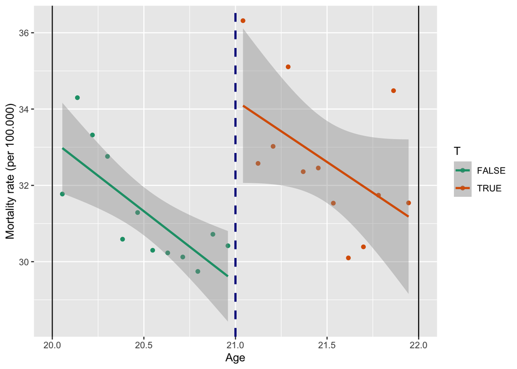

```r
ggplot(data_h, aes(x = agecell, y = mva, color = T)) +
geom_point() +
geom_smooth(method = "lm") +
scale_color_brewer(palette = "Dark2") +
geom_vline(xintercept = 21, color = "darkblue", size = 1, linetype = "dashed") +
geom_vline(xintercept = 20) +
geom_vline(xintercept = 22) +
labs(y = "Mortality rate (per 100.000)",
     x = "Age")
```

###### Наркотики

```r
mod_drugs <- lm(drugs ~ agecell + T, data = data_h)
summary(mod_drugs)
```

```
##
## Call:
## lm(formula = drugs ~ agecell + T, data = data_h)
##
## Residuals:
##      Min       1Q   Median       3Q      Max
## -0.62926 -0.27343  0.02269  0.29434  0.42476
##
## Coefficients:
##             Estimate Std. Error t value Pr(>|t|)
## (Intercept)  -4.9942     4.9216  -1.015   0.3218
## agecell       0.4355     0.2400   1.815   0.0838 .
## TTRUE         0.2065     0.2730   0.756   0.4578
## ---
## Signif. codes:  0 '***' 0.001 '**' 0.01 '*' 0.05 '.' 0.1 ' ' 1
##
## Residual standard error: 0.3335 on 21 degrees of freedom
##   (2 пропущенных наблюдений удалены)
## Multiple R-squared:  0.5446, Adjusted R-squared:  0.5013
## F-statistic: 12.56 on 2 and 21 DF,  p-value: 0.0002587
```

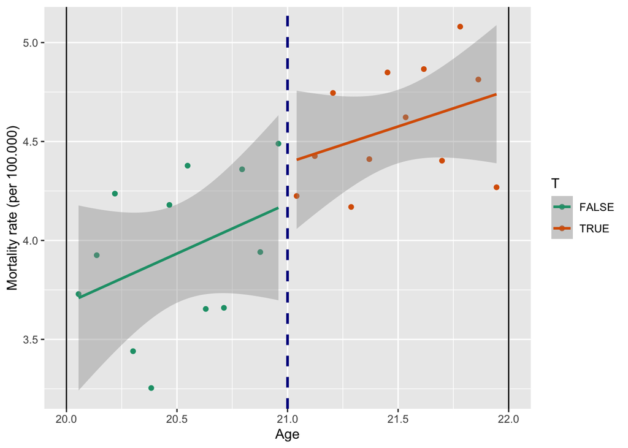

```r
ggplot(data_h, aes(x = agecell, y = drugs, color = T)) +
geom_point() +
geom_smooth(method = "lm") +
scale_color_brewer(palette = "Dark2") +
geom_vline(xintercept = 21, color = "darkblue", size = 1, linetype = "dashed") +
geom_vline(xintercept = 20) +
geom_vline(xintercept = 22) +
labs(y = "Mortality rate (per 100.000)",
     x = "Age")
```

###### Прочие внешние причины

```r
mod_externalother <- lm(externalother ~ agecell + T, data = data_h)
summary(mod_externalother)
```

```
##
## Call:
## lm(formula = externalother ~ agecell + T, data = data_h)
##
## Residuals:
##      Min       1Q   Median       3Q      Max
## -1.14575 -0.38546 -0.00161  0.35788  0.85794
##
## Coefficients:
##             Estimate Std. Error t value Pr(>|t|)
## (Intercept)  13.1630     7.8140   1.685    0.107
## agecell      -0.1856     0.3810  -0.487    0.631
## TTRUE         0.8308     0.4335   1.917    0.069 .
## ---
## Signif. codes:  0 '***' 0.001 '**' 0.01 '*' 0.05 '.' 0.1 ' ' 1
##
## Residual standard error: 0.5295 on 21 degrees of freedom
##   (2 пропущенных наблюдений удалены)
## Multiple R-squared:  0.305,  Adjusted R-squared:  0.2388
## F-statistic: 4.608 on 2 and 21 DF,  p-value: 0.02192
```

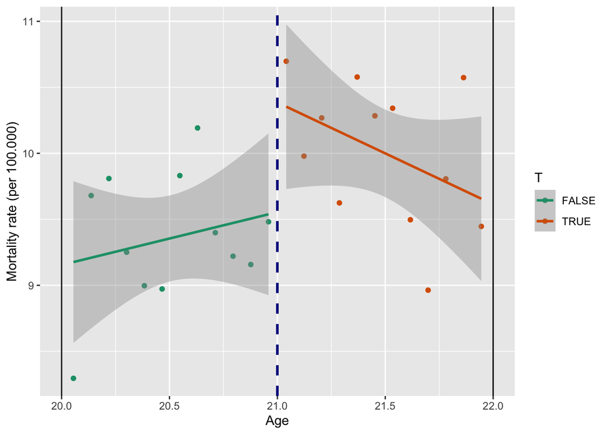

```r
ggplot(data_h, aes(x = agecell, y = externalother, color = T)) +
geom_point() +
geom_smooth(method = "lm") +
scale_color_brewer(palette = "Dark2") +
geom_vline(xintercept = 21, color = "darkblue", size = 1, linetype = "dashed") +
geom_vline(xintercept = 20) +
geom_vline(xintercept = 22) +
labs(y = "Mortality rate (per 100.000)",
     x = "Age")
```

### 2.3. С помощью пакета rdd

Теперь та же оценка, но с помощью специального пакета, где можно выбрать ядра и ширину окна.

#### 2.3.1. Выбор окна

Мы можем установить любое окно вручную, используя аргумент `bw`, а также ядро с помощью аргумента `kernel`:

```r
library(rdd)

mod_rdd <- RDestimate(all ~ agecell, data=data, cutpoint = 21, bw = 1)
summary(mod_rdd)
```

```
##
## Call:
## RDestimate(formula = all ~ agecell, data = data, cutpoint = 21,
##     bw = 1)
##
## Type:
## sharp
##
## Estimates:
##            Bandwidth  Observations  Estimate  Std. Error  z value  Pr(>|z|)
## LATE       1.0        24            9.700     1.932       5.022    5.112e-07
## Half-BW    0.5        12            9.567     2.118       4.517    6.283e-06
## Double-BW  2.0        48            8.381     1.345       6.232    4.603e-10
##
## LATE       ***
## Half-BW    ***
## Double-BW  ***
## ---
## Signif. codes:  0 '***' 0.001 '**' 0.01 '*' 0.05 '.' 0.1 ' ' 1
##
## F-statistics:
##            F      Num. DoF  Denom. DoF  p
## LATE       26.74  3         20          6.711e-07
## Half-BW    15.27  3          8          2.257e-03
## Double-BW  36.57  3         44          1.024e-11
```

- Bandwidth – ширина окна
- Observations – количество наблюдений, которые попали в окно
- Estimate – оценка эффекта
- Std. Error стандартная ошибка
- Pr(>|z|) – p-value

Видим, что оценка совпала практически в точности с той, что мы получили вручную (в п. 2.2 получили эффект 9.753).

Далее воспользуемся встренной опцией расчета оптимальной ширины окна:

```r
mod_rdd1 <- RDestimate(all ~ agecell, data=data, cutpoint = 21)
summary(mod_rdd1)
```

```
##
## Call:
## RDestimate(formula = all ~ agecell, data = data, cutpoint = 21)
##
## Type:
## sharp
##
## Estimates:
##            Bandwidth  Observations  Estimate  Std. Error  z value  Pr(>|z|)
## LATE       1.6561     40            9.001     1.480       6.080    1.199e-09
## Half-BW    0.8281     20            9.579     1.914       5.004    5.609e-07
## Double-BW  3.3123     48            7.953     1.278       6.223    4.882e-10
##
## LATE       ***
## Half-BW    ***
## Double-BW  ***
## ---
## Signif. codes:  0 '***' 0.001 '**' 0.01 '*' 0.05 '.' 0.1 ' ' 1
##
## F-statistics:
##            F      Num. DoF  Denom. DoF  p
## LATE       33.08  3         36          3.799e-10
## Half-BW    29.05  3         16          2.078e-06
## Double-BW  32.54  3         44          6.129e-11
```

Оказалось, что оптимальное окно шире того, что мы использовали и равно 1.65.

#### 2.3.2. Выбор ядер

Проверим на робастность с разными ядрами.

Веса из равномерного распределения одинаковые всех наблюдений, поэтму оценка почти совпадает с МНК, в остальных случаях оценка получилась выше и примерно равна 9.

Аналогичным образом мы можем проверить разрыв по всем видам причин.

##### Прямоугольное (равномерное)

```r
mod_kernel1 <- RDestimate(all ~ agecell, data = data, cutpoint = 21, kernel = "rectangular")
summary(mod_kernel1)
```

```
##
## Call:
## RDestimate(formula = all ~ agecell, data = data, cutpoint = 21,
##     kernel = "rectangular")
##
## Type:
## sharp
##
## Estimates:
##            Bandwidth  Observations  Estimate  Std. Error  z value  Pr(>|z|)
## LATE       2.603      48            7.663     1.273       6.017    1.776e-09
## Half-BW    1.302      32            9.094     1.498       6.072    1.267e-09
## Double-BW  5.207      48            7.663     1.273       6.017    1.776e-09
##
## LATE       ***
## Half-BW    ***
## Double-BW  ***
## ---
## Signif. codes:  0 '***' 0.001 '**' 0.01 '*' 0.05 '.' 0.1 ' ' 1
##
## F-statistics:
##            F      Num. DoF  Denom. DoF  p
## LATE       29.47  3         44          2.651e-10
## Half-BW    21.81  3         28          3.470e-07
## Double-BW  29.47  3         44          2.651e-10
```

##### Треугольное

```r
mod_kernel2 <- RDestimate(all ~ agecell, data=data, cutpoint = 21, kernel = "triangular")
summary(mod_kernel2)
```

```
##
## Call:
## RDestimate(formula = all ~ agecell, data = data, cutpoint = 21,
##     kernel = "triangular")
##
## Type:
## sharp
##
## Estimates:
##            Bandwidth  Observations  Estimate  Std. Error  z value  Pr(>|z|)
## LATE       1.6561     40            9.001     1.480       6.080    1.199e-09
## Half-BW    0.8281     20            9.579     1.914       5.004    5.609e-07
## Double-BW  3.3123     48            7.953     1.278       6.223    4.882e-10
##
## LATE       ***
## Half-BW    ***
## Double-BW  ***
## ---
## Signif. codes:  0 '***' 0.001 '**' 0.01 '*' 0.05 '.' 0.1 ' ' 1
##
## F-statistics:
##            F      Num. DoF  Denom. DoF  p
## LATE       33.08  3         36          3.799e-10
## Half-BW    29.05  3         16          2.078e-06
## Double-BW  32.54  3         44          6.129e-11
```

##### Епанечникова

```r
mod_kernel3 <- RDestimate(all ~ agecell, data=data, cutpoint = 21, kernel = "epanechnikov")
summary(mod_kernel3)
```

```
##
## Call:
## RDestimate(formula = all ~ agecell, data = data, cutpoint = 21,
##     kernel = "epanechnikov")
##
## Type:
## sharp
##
## Estimates:
##            Bandwidth  Observations  Estimate  Std. Error  z value  Pr(>|z|)
## LATE       1.5417     38            9.079     1.480       6.135    8.502e-10
## Half-BW    0.7708     18            9.450     1.998       4.730    2.242e-06
## Double-BW  3.0833     48            7.779     1.271       6.121    9.298e-10
##
## LATE       ***
## Half-BW    ***
## Double-BW  ***
## ---
## Signif. codes:  0 '***' 0.001 '**' 0.01 '*' 0.05 '.' 0.1 ' ' 1
##
## F-statistics:
##            F      Num. DoF  Denom. DoF  p
## LATE       29.18  3         34          3.205e-09
## Half-BW    26.01  3         14          1.104e-05
## Double-BW  30.70  3         44          1.457e-10
```

##### Квадратное

```r
mod_kernel4 <- RDestimate(all ~ agecell, data=data, cutpoint = 21, kernel = "quartic")
summary(mod_kernel4)
```

```
##
## Call:
## RDestimate(formula = all ~ agecell, data = data, cutpoint = 21,
##     kernel = "quartic")
##
## Type:
## sharp
##
## Estimates:
##            Bandwidth  Observations  Estimate  Std. Error  z value  Pr(>|z|)
## LATE       1.7603     42            9.046     1.469       6.157    7.415e-10
## Half-BW    0.8801     22            9.445     1.950       4.845    1.269e-06
## Double-BW  3.5205     48            7.842     1.271       6.168    6.904e-10
##
## LATE       ***
## Half-BW    ***
## Double-BW  ***
## ---
## Signif. codes:  0 '***' 0.001 '**' 0.01 '*' 0.05 '.' 0.1 ' ' 1
##
## F-statistics:
##            F      Num. DoF  Denom. DoF  p
## LATE       34.26  3         38          1.350e-10
## Half-BW    32.25  3         18          3.759e-07
## Double-BW  31.29  3         44          1.100e-10
```

##### Гауссиан

```r
mod_kernel5 <- RDestimate(all ~ agecell, data=data, cutpoint = 21, kernel = "gaussian")
summary(mod_kernel5)
```

```
##
## Call:
## RDestimate(formula = all ~ agecell, data = data, cutpoint = 21,
##     kernel = "gaussian")
##
## Type:
## sharp
##
## Estimates:
##            Bandwidth  Observations  Estimate  Std. Error  z value  Pr(>|z|)
## LATE       0.6064     48            9.068     1.490       6.084    1.172e-09
## Half-BW    0.3032     48            9.431     1.838       5.132    2.869e-07
## Double-BW  1.2128     48            8.027     1.279       6.279    3.418e-10
##
## LATE       ***
## Half-BW    ***
## Double-BW  ***
## ---
## Signif. codes:  0 '***' 0.001 '**' 0.01 '*' 0.05 '.' 0.1 ' ' 1
##
## F-statistics:
##            F      Num. DoF  Denom. DoF  p
## LATE       44.94  3         44          3.770e-13
## Half-BW    73.65  3         44          0.000e+00
## Double-BW  33.02  3         44          4.915e-11
```

### 2.4. Bias-variance tradeoff

```r
est<-c()
se<-c()
for (i in 1:3){
  reg_rdd <- RDestimate(all ~ agecell, data = data, cutpoint = 21, bw=i, kernel = "triangular")
  est[i]<-reg_rdd$est[1]
  se[i]<-reg_rdd$se[1]
}
```

```r
CIlow <- est - 1.96*se
CIup <- est + 1.96*se
```

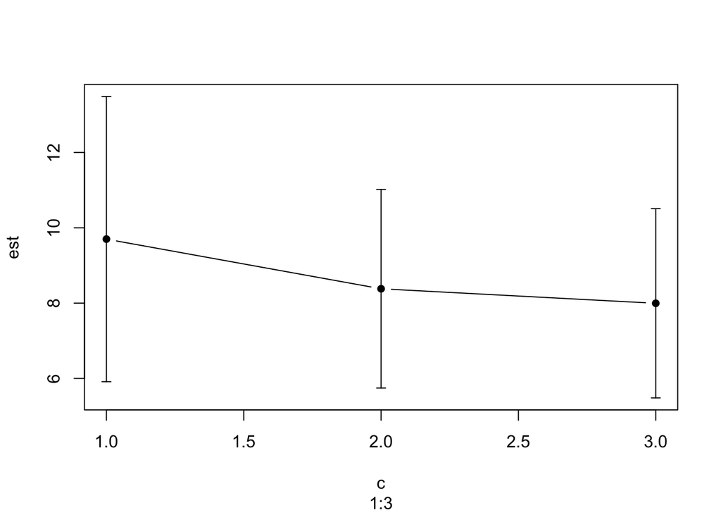

```r
library(Hmisc)
errbar(x = c(1:3), y = est, yplus = CIup, yminus = CIlow, type = 'b')
```

### 2.5. Плацебо тест

#### 2.5.1. Отсечка левее

```r
data_new <- data[data$agecell < 21,]
```

Отсечка 20

```r
mod_rdd_20 <- RDestimate(all ~ agecell, data = data_new, cutpoint = 20, kernel = "triangular")
summary(mod_rdd_20)
```

```
##
## Call:
## RDestimate(formula = all ~ agecell, data = data_new, cutpoint = 20,
##     kernel = "triangular")
##
## Type:
## sharp
##
## Estimates:
##            Bandwidth  Observations  Estimate  Std. Error  z value  Pr(>|z|)
## LATE       0.5553     14             0.7998   3.209        0.2493  0.8032
## Half-BW    0.2777      7            -3.4455   2.663       -1.2940  0.1956
## Double-BW  1.1107     24             0.7401   2.088        0.3544  0.7230
## ---
## Signif. codes:  0 '***' 0.001 '**' 0.01 '*' 0.05 '.' 0.1 ' ' 1
##
## F-statistics:
##            F       Num. DoF  Denom. DoF  p
## LATE       0.5695  3         10          0.7047
## Half-BW    0.5823  3          3          0.6678
## Double-BW  1.4173  3         20          0.5342
```

Отсечка 20.5

```r
mod_rdd_20.5 <- RDestimate(all ~ agecell, data = data_new, cutpoint = 20.5, kernel = "triangular")
summary(mod_rdd_20.5)
```

```
##
## Call:
## RDestimate(formula = all ~ agecell, data = data_new, cutpoint = 20.5,
##     kernel = "triangular")
##
## Type:
## sharp
##
## Estimates:
##            Bandwidth  Observations  Estimate  Std. Error  z value  Pr(>|z|)
## LATE       0.4051     10            2.3938    1.7961      1.3328   0.1826
## Half-BW    0.2025      5            0.9779    0.7401      1.3212   0.1864
## Double-BW  0.8101     16            0.4816    1.3249      0.3635   0.7162
## ---
## Signif. codes:  0 '***' 0.001 '**' 0.01 '*' 0.05 '.' 0.1 ' ' 1
##
## F-statistics:
##            F       Num. DoF  Denom. DoF  p
## LATE       1.4778  3          6          0.6246
## Half-BW    1.6303  3          1          0.9813
## Double-BW  0.9465  3         12          0.8978
```

#### 2.5.2. Отсечка правее

```r
data_new2 <- data[data$agecell > 21,]
```

Отсечка 22

```r
mod_rdd_22 <- RDestimate(all ~ agecell, data = data_new2, cutpoint = 22, kernel = "triangular")
summary(mod_rdd_22)
```

```
##
## Call:
## RDestimate(formula = all ~ agecell, data = data_new2, cutpoint = 22,
##     kernel = "triangular")
##
## Type:
## sharp
##
## Estimates:
##            Bandwidth  Observations  Estimate  Std. Error  z value  Pr(>|z|)
## LATE       0.8808     22            -0.2917   2.125       -0.1373  0.8908
## Half-BW    0.4404     11            -0.6552   3.344       -0.1959  0.8447
## Double-BW  1.7616     24             0.2413   1.894        0.1274  0.8986
## ---
## Signif. codes:  0 '***' 0.001 '**' 0.01 '*' 0.05 '.' 0.1 ' ' 1
##
## F-statistics:
##            F       Num. DoF  Denom. DoF  p
## LATE       1.1277  3         18          0.72852
## Half-BW    0.2613  3          7          0.29760
## Double-BW  3.4606  3         20          0.07151
```

# 3. Размытая разрывная регрессия

Как известно, строгость правил смягчается необязательностью их исполнения, именно под этим слоганом работает метод размытой разрывной регрессии. В прошлом пукте мы предполагали, что все, у кого running variable больше cutoff, попадают в группу воздействия. Однако это не всегда бывает так. Бывает, что несмотря на предписание оказаться в группе воздействия, человек отказывается от этой опции или несмотря на то, что человеку предписано быть в контрольной группе, он находит возможность оказаться в группе воздействия. То есть мы снова столкнулись с ситуацией эндогенного тритмента.

Снова начнем с **обозначений**:

- $Z=\{R>c\}$ – переменная предписания, она же инструментальная переменная (instrumental variable), почему она является инструментом обсудим далее.
- $T(1), T(0)$ – переменная воздействия (treatment variable), теперь тоже с потенциальными исходами (в данном случае еще и переменная интереса).
- $Y(00), Y(10), Y(01), Y(11)$ – потенциальные исходы (potential outcomes), зависимая переменная. Например $Y(01)$, означает, что человеку было придписано оказаться в контрольной группе $Z=0$, а реально он смог найти возможность попасть в группу воздействия $T=1$.
- $X$ – независимые переменные (covariates), контрольные переменные.

Как и раньше, мы наблюдаем только $Y, Z, T, X$, где $T=Z T(1)+(1-Z) T(0)$ – реализовавшийся тритмент, который мы наблюдаем.

Теперь помомо того, что наш тритмент эндогенен в связи с тем, что предписания выдается на основе достижения отсечки по бегущей переменной, наша ситуация осложнилась тем, что индивиды самостоятельно могут принимать решение о том, в какую группу (тритмент или контроль) они попадают $R \rightarrow Z \rightarrow T \rightarrow Y$. Мы уже встречались с похожей ситуацией в модели LATE, в соотвествии с этим мы вводили **классификацию наблюдений**:

- Always takers: $T_1=1, T_0=1$
- Compliers: $T_1=1, T_0=0$
- Never takers: $T_1=0, T_0=0$
- Defiers: $T_1=0, T_0=1$

Тогда нам помог побороть эту сложность **метод инструментальных переменных**. Сейчас мы обратимся к нему снова:

- Хотим оценить: Reduced form (Intention to treat): $Z \rightarrow Y$
- **Реально можем оценить:**
  - First stage: $Z \rightarrow T$
  - Second stage: $T \rightarrow Y$

**Предпосылки:**

- $\left(Y_{i j}, T_i, X\right) \perp Z$ – рандомизация
- $Y(T, Z=1)=Y(T, Z=0)$ – exclusion restriction: напрямую $\mathrm{T}$ влияет на $\mathrm{Y}$, а не $Z$ напрямую не влияет на $Y$
- SUTVA
- $\left. T\right|_{Z=1} \geq \left. T\right|_{Z=0}$ – монотонность
  - Мы хотим, чтобы никогда не было $T_1<T_0$, но бывало такое, что $T_1>T_0$
  - Бывает одностороннее неповиновение тритменту (one-sided noncompliance) – no Defiers and no Always takers
  - Бывает двустороннее неповиновение тритменту (two-sided noncompliance) – no Defiers
- $P\left(T_1 \geq T_0\right)=1$ – монотонность.
- Главное предположение разрывной регрессии – предположим непрерывность всего: $E\left(Y_{00} \mid R\right), E\left(Y_{01} \mid R\right), E\left(Y_{10} \mid R\right), E\left(Y_{11} \mid R\right)$, $E\left(T_0 \mid R\right), E\left(T_1 \mid R\right), E(X \mid R)$

Когда выполнены все эти предпосылки, мы говорим, что эффект идентифицирован.

На рисунках ниже представлены иллюстрации неповиновения тритменту и отличия четкой разрывной регрессии от размытой:

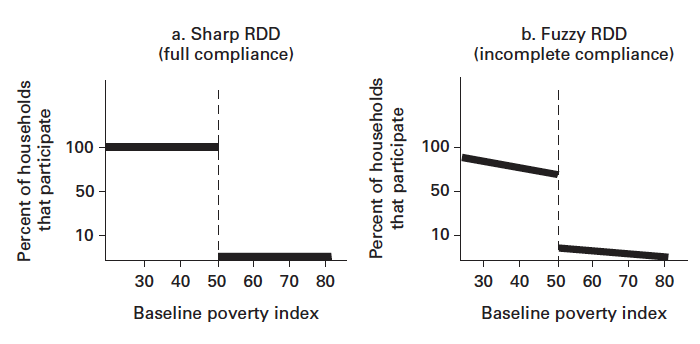

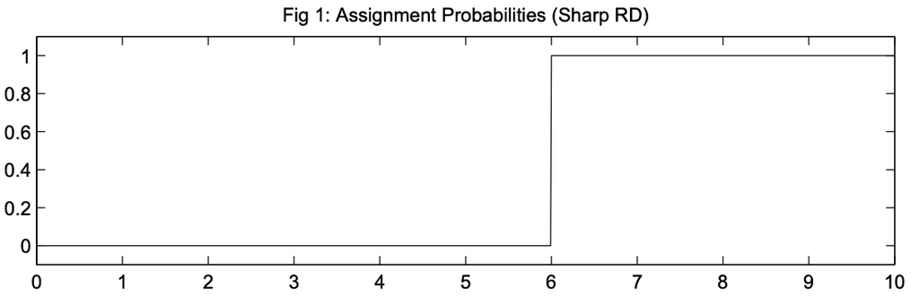

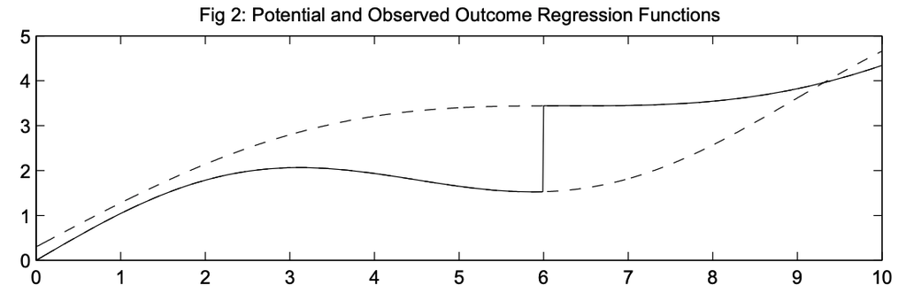

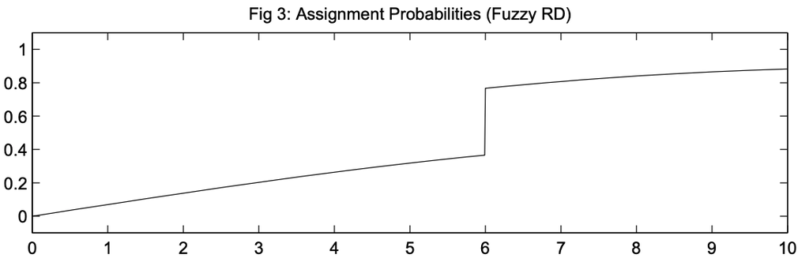

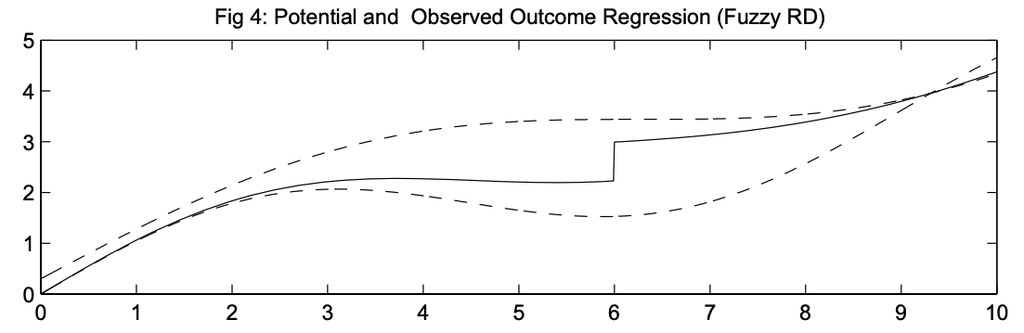

**Формулы:**

$\mathrm{ITT}_T=\bar{T}_{Z=1}-\bar{T}_{Z=0}=P \text { (compliers) }$ (оценка первого шага), физический смысл – доля комплаеров в выборке

$\mathrm{ITT}_Y=\bar{Y}_{Z=1}-\bar{Y}_{Z=0}$ (оценка второго шага), физический смысл – “оценка эффекта от намерения”, Intention to treat

$\mathrm{TE}=\frac{\mathrm{ITT}_Y}{\mathrm{ITT}_T}=E(\tau \mid \text { Compliers })=\text { LATE }$ – тритмент эффект для комплаеров, численно совпадает с оценкой с помощью метода инструментальных переменных

$\tau_{FRD} = \frac{\underset{R \rightarrow c+}{lim} E [Y|R] - \underset{R \rightarrow c-}{lim} E [Y|R]}{\underset{R \rightarrow c+}{lim} E [T|R] - \underset{R \rightarrow c-}{lim} E [T|R]}$

# 4. Пример размытой разрывной регрессии

Набор данных содержит 4 столбца:

- id – идентификатор студента
- entry_exam – оценка студента за экзамен в начале года (из 100)
- exit_exam – оценка студента за итоговый экзамен в конце года (из 100)
- tutoring – индикаторная переменная, показывающая, был ли учащийся зачислен в программу обучения

```r
library(readr)
tutoring <- read_csv("Seminar_12-13_regression_discontinuity_data/tutoring_program_fuzzy.csv")
head(tutoring)
```

| id | entrance_exam | tutoring | tutoring_text | exit_exam |
| --- | --- | --- | --- | --- |
| 1 | 92.40833 | FALSE | No tutor | 78.07592 |
| 2 | 72.77238 | FALSE | No tutor | 58.21757 |
| 3 | 53.65090 | TRUE | Tutor | 61.96543 |
| 4 | 98.32688 | FALSE | No tutor | 67.48956 |
| 5 | 69.71219 | TRUE | Tutor | 54.12888 |
| 6 | 68.06771 | TRUE | Tutor | 60.13143 |

## 4.1. Предватрительный анализ и выбор дизайна

В предыдущем примере с четкой разрывной регрессией мы смогли легко оценить размер скачка в точке отсечки, потому что не было неповиновения тритменту. Для нас было бы идеальной ситуацией, если бы никто из людей, набравших баллы выше порога, не использовал бы дополнительные занятия, и никто из тех, кто имел право на такие занятия, не отказывался бы от них.

Тем не менее, это не так. В реальных данных большая редкость встретить такой дизайн. В нашем случае возможно, что некоторые люди набрали более высокие баллы на вступительном экзамене и все равно записались на дополнительные занятия, или что некоторые люди набрали ниже порога, но отказались от дополнительных занятий.

Чаще всего в данных ситуация выглядит так:

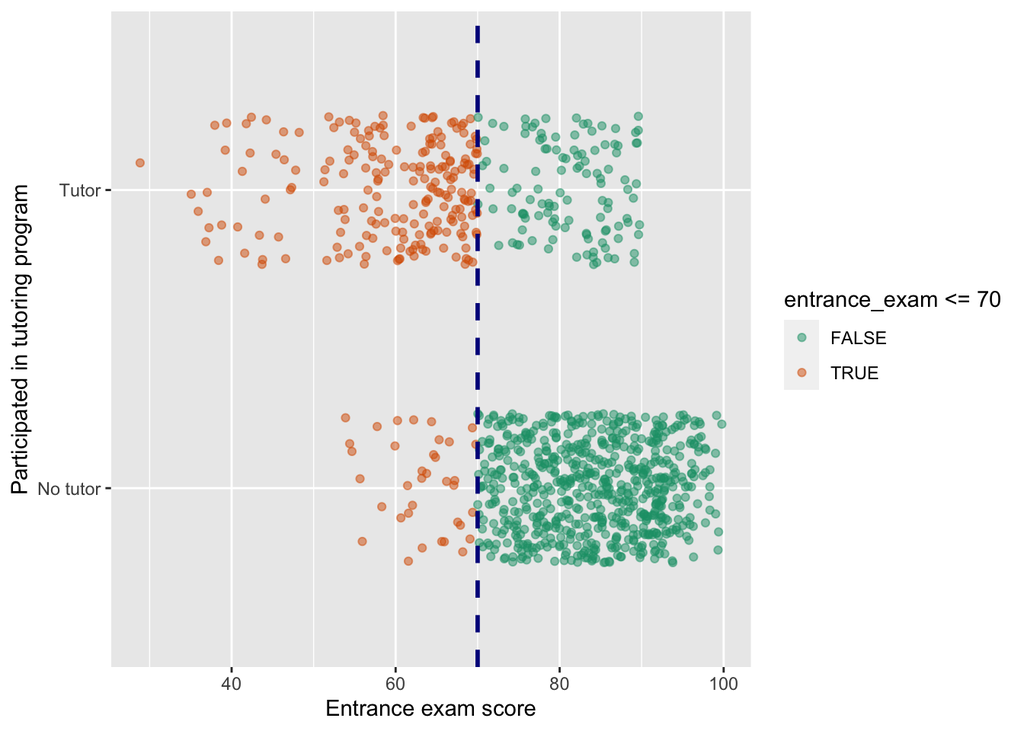

```r
library(ggplot2)
ggplot(tutoring, aes(x = entrance_exam, y = tutoring_text, color = entrance_exam <= 70)) +
  geom_point(size = 1.5, alpha = 0.5,
             position = position_jitter(width = 0, height = 0.25, seed = 1234)) +
  geom_vline(xintercept = 70, color = 'darkblue', size = 1, linetype = 'dashed') +
  scale_color_brewer(palette = "Dark2") +
  labs(x = "Entrance exam score", y = "Participated in tutoring program")
```

Мы видим, что довольно много людей не выполнили то, что им предписывало распределение в тритмент. Есть люди, которые несмотря на низкие баллы, отказались от занятий (оранжевые точки левее синей черты cutoff, категория no tutor) и те, которые набрав высокий балл на экзамене, все равно записались на занятия (зеленые точки правее синей черты cutoff, категория tutor).

Мы можем даже посчитать, какую долю они составляют в выборке:

```r
library(dplyr)
tutoring %>%
  group_by(tutoring, entrance_exam <= 70) %>%
  dplyr::summarize(count = n()) %>%
  group_by(tutoring) %>%
  mutate(prop = count / sum(count))
```

| tutoring | entrance_exam <= 70 | count | prop |
| --- | --- | --- | --- |
| FALSE | FALSE | 646 | 0.94721408 |
| FALSE | TRUE | 36 | 0.05278592 |
| TRUE | FALSE | 116 | 0.36477987 |
| TRUE | TRUE | 202 | 0.63522013 |

## 4.2. Визуализация разрыва

При четкой разрывной регресии наша цель состоит в том, чтобы измерить размер разрыва прямо в точке отсечки. Сейчас такая оценка не сработает, потому что у нас есть проблемы с неповиновением тритменту. Нарисуем это на графике с линиями регрессий:

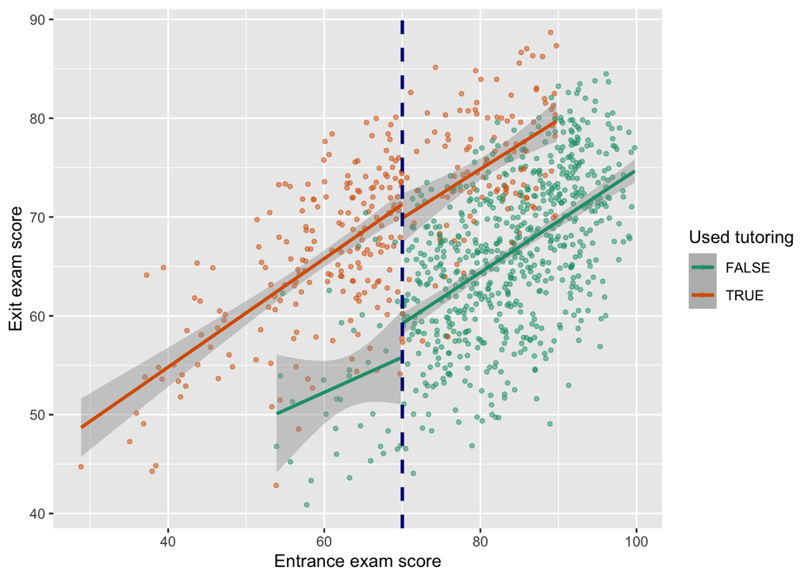

```r
ggplot(tutoring, aes(x = entrance_exam, y = exit_exam, color = tutoring)) +
  geom_point(size = 1, alpha = 0.5) +
  geom_smooth(data = filter(tutoring, entrance_exam <= 70), method = "lm") +
  geom_smooth(data = filter(tutoring, entrance_exam > 70), method = "lm") +
  geom_vline(xintercept = 70, color = "darkblue", size = 1, linetype = "dashed") +
  scale_color_brewer(palette = "Dark2") +
  labs(x = "Entrance exam score", y = "Exit exam score", color = "Used tutoring")
```

в точке 70 баллов виден разрыв, но есть люди, которые использовали и не использовали программу по обе стороны отсечки.

Другой способ взглянуть на это — построить своего рода гистограмму, показывающую вероятность участия в группе дополнительных занятий при разных баллах вступительных экзаменов.

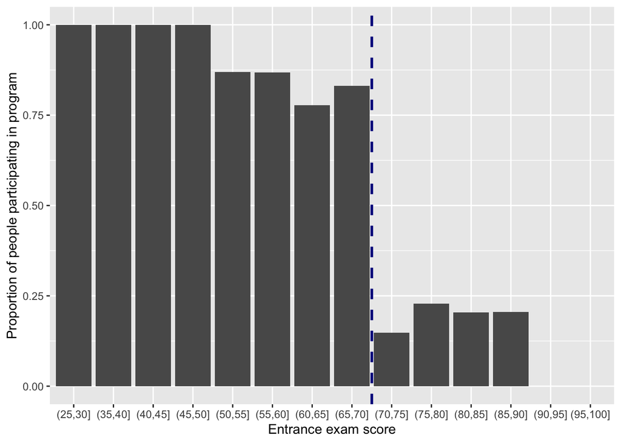

```r
library(tidyr)

tutoring_with_bins <- tutoring %>%
  mutate(exam_binned = cut(entrance_exam, breaks = seq(0, 100, 5))) %>%
  group_by(exam_binned, tutoring) %>%
  dplyr::summarize(n = n()) %>%
  pivot_wider(names_from = "tutoring", values_from = "n", values_fill = 0) %>%
  rename(tutor_yes = `TRUE`, tutor_no = `FALSE`) %>%
  mutate(prob_tutoring = tutor_yes / (tutor_yes + tutor_no))

ggplot(tutoring_with_bins, aes(x = exam_binned, y = prob_tutoring)) +
  geom_col() +
  geom_vline(xintercept = 8.5, color = "darkblue", size = 1, linetype = "dashed") +
  scale_color_brewer(palette = "Dark2") +
  labs(x = "Entrance exam score", y = "Proportion of people participating in program")
```

## 4.3. Оценка разрыва

Как было сказано ранее, проблему неповиновения тритменту решаем метод инструментальных переменных. Инструмент довольно прост и понятен: мы создаем переменную, которая указывает, находится ли кто-то выше или ниже порога. Эта переменная по существу измеряет то, что должно было произойти, а не то, что произошло на самом деле.

Эта переменная отвечает всем требованиям инструмента:

- Relevance $(Z \rightarrow X$ and $\operatorname{Cor}(Z, X) \neq 0)$ : The cutoff causes access to the tutoring program.
- Exclusion $(Z \rightarrow X \rightarrow Y$ and $Z \nrightarrow Y$ and $\operatorname{Cor}(Z, Y \mid X)=0$ ): The cutoff causes exit exam scores only through the tutoring program.
- Exogeneity $(U \nrightarrow Z$ and $\operatorname{Cor}(Z, U)=0$ ): Unobserved confounders between the tutoring program and exit exam scores are unrelated to the cutoff.

### 4.3.1 Нечеткая параметрическая оценка

Делаем инструмент! Мы также центрируем текущую переменную так же, как мы делали это с резким разрывом регрессии:

Создадим переменную инструмента. Но перед этим “центрируем наши данные”. Технически мы этим ничего не нарушаем и ничего от этого не теряем, но после центрирования мы сможем интерпретировать эфект как “при прочих равных условиях, учащиеся, посещавшие дополнительные занятия набрали на экзамене на X баллов больше порога, чем те, кто не ходили”.

```r
tutoring_centered <- tutoring %>%
  mutate(entrance_centered = entrance_exam - 70,
         below_cutoff = entrance_exam <= 70)
tutoring_centered
```

| id | entrance_exam | tutoring | tutoring_text | exit_exam | entrance_centered | below_cutoff |
| --- | --- | --- | --- | --- | --- | --- |
| 1 | 92.40833 | FALSE | No tutor | 78.07592 | 22.40832520 | FALSE |
| 2 | 72.77238 | FALSE | No tutor | 58.21757 | 2.77237972 | FALSE |
| 3 | 53.65090 | TRUE | Tutor | 61.96543 | -16.34910163 | TRUE |
| 4 | 98.32688 | FALSE | No tutor | 67.48956 | 28.32688290 | FALSE |
| 5 | 69.71219 | TRUE | Tutor | 54.12888 | -0.28780635 | TRUE |
| 6 | 68.06771 | TRUE | Tutor | 60.13143 | -1.93228986 | TRUE |
| 7 | 86.03048 | FALSE | No tutor | 73.05074 | 16.03047601 | FALSE |
| 8 | 85.68573 | TRUE | Tutor | 76.73620 | 15.68573263 | FALSE |
| 9 | 85.90494 | FALSE | No tutor | 57.78114 | 15.90494416 | FALSE |
| 10 | 89.52848 | FALSE | No tutor | 79.91583 | 19.52847789 | FALSE |

[output cut: 990 more lines]

Прежде чем использовать инструмент, ради интереса построим модель, которая предполагает дизайн четкой разрывной регрессии:

$Exit\_exam = \beta_0 + \beta_1 Entrance\_exam\_score_{centered} + \beta_2 Tutoring\_programm + \varepsilon$

Мы будем использовать окно 10 баллов:

```r
model_sans_instrument <- lm(exit_exam ~ entrance_centered + tutoring,
                            data = filter(tutoring_centered,
                                          entrance_centered >= -10 &
                                            entrance_centered <= 10))
stargazer(model_sans_instrument, type = 'text')
```

```
##
## ===============================================
##                         Dependent variable:
##                     ---------------------------
##                              exit_exam
## -----------------------------------------------
## entrance_centered            0.511***
##                               (0.067)
##
## tutoring                     11.484***
##                               (0.744)
##
## Constant                     59.274***
##                               (0.503)
##
## -----------------------------------------------
## Observations                    403
## R2                             0.373
## Adjusted R2                    0.370
## Residual Std. Error      6.465 (df = 400)
## F Statistic          119.103*** (df = 2; 400)
## ===============================================
## Note:               *p<0.1; **p<0.05; ***p<0.01
```

Альтернативный сопосб посмотреть на результаты регрессии:

```r
library(broom) # Convert models to data frames
tidy(model_sans_instrument)
```

| term | estimate | std.error | statistic | p.value |
| --- | --- | --- | --- | --- |
| (Intercept) | 59.2740328 | 0.50286725 | 117.872128 | 9.749764e-313 |
| entrance_centered | 0.5113075 | 0.06650396 | 7.688376 | 1.167266e-13 |
| tutoringTRUE | 11.4844471 | 0.74427520 | 15.430377 | 1.768596e-42 |

Коэффициент tutoring показывает размер скачка, который значим и равен 11,5. Это означает, что участие в дополнительных занятиях приводит к повышению результата на 11,5 баллов на итоговом экзамене.

НО ЭТО НЕПРАВИЛЬНО. У нас дизайн размытой регрессии, поэтому так делать нельзя. Вместо этого нам нужно оценить модель 2МНК, которая включает инструмент на первом шаге, что затем устранит эндогенность, встроенную в тритмент (участие в занятиях). Оценим этот набор моделей:

$$\text { Tutoring program }=\gamma_0+\gamma_1 \text { Entrance exam score
}_{\text {centered }}+\gamma_2 \text { Below cutoff }+\omega$$
$$\text { Exit exam }=\beta_0+\beta_1 \text { Entrance exam score }_{\text
{centered }}+\beta_2 \text { Tutoring program }+\epsilon$$

Мы могли бы вручную сначала оценить модель первого шага, затем построить прогнозное значение тритмента и использовать эти предсказанные значения в модели второго шага, но вместо этого мы доверим эту работу функции iv_robust() из пакета estimatr.

```r
library(estimatr)
model_fuzzy <- iv_robust(
  exit_exam ~ entrance_centered + tutoring | entrance_centered + below_cutoff,
  data = filter(tutoring_centered, entrance_centered >= -10 & entrance_centered <= 10)
)
tidy(model_fuzzy)
```

| term | estimate | std.error | statistic | p.value | conf.low | conf.high | df | outcome |
| --- | --- | --- | --- | --- | --- | --- | --- | --- |
| (Intercept) | 60.1413558 | 1.01765573 | 59.097939 | 9.746624e-200 | 58.1407338 | 62.1419778 | 400 | exit_exam |
| entrance_centered | 0.4366281 | 0.09929619 | 4.397229 | 1.407213e-05 | 0.2414205 | 0.6318357 | 400 | exit_exam |
| tutoringTRUE | 9.7410444 | 1.91184891 | 5.095091 | 5.384163e-07 | 5.9825170 | 13.4995718 | 400 | exit_exam |

Опираясь на эту модель, используя в качестве инструментаниже_отсечки, мы видим, что коэффициент для tutoringTRUE теперь другой! Это 9,74, что означает, что программа репетиторства вызывает средний прирост на 9,74 балла на выпускном экзамене для комплаеров в пропускной способности.

Теперь сравним результаты, построенные с помощью четкого и размытого дизайна, разница ощутима:

```r
library(modelsummary)
library(kableExtra)
modelsummary(list("No instrument (wrong)" = model_sans_instrument,
                  "Fuzzy RD (bw = 10)" = model_fuzzy),
             gof_omit = 'IC|Log|Adj|p\\.value|statistic|se_type',
             stars = TRUE) %>%
  row_spec(5, background = "#F5ABEA")
```

|  | No instrument (wrong) | Fuzzy RD (bw = 10) |
| --- | --- | --- |
| (Intercept) | 59.274*** | 60.141*** |
|  | (0.503) | (1.018) |
| entrance_centered | 0.511*** | 0.437*** |
|  | (0.067) | (0.099) |
| tutoringTRUE | 11.484*** | 9.741*** |
|  | (0.744) | (1.912) |
| Num.Obs. | 403 | 403 |
| R2 | 0.373 | 0.365 |
| F | 119.103 |  |
| RMSE | 6.44 | 6.48 |

Далее мы можем и должны разным образом проверять устойчивость – менять ширину окна, использовать ядра, проводить плацебо тесты, но второй раз этого делать не будем.

### 4.3.2 Нечеткое непараметрическое оценивание

Мы также можем использовать непараметрические методы для оценки разрыва на границе отсечки.

Мы будем использовать rdrobust().

Чтобы выполнить нечеткую оценку с помощью rdrobust(), используйте fuzzy аргумент, чтобы указать столбец тритмента (или обучения в нашем случае).

Вам не нужно указывать инструмент (или даже создавать его!). Все, что вам нужно указать, — это столбец, указывающий статус обработки — rdrobust() сделает за вас все выше/ниже предельных значений инструментов за кулисами.

```r
library(rdrobust)
rdrobust(y = tutoring$exit_exam,
         x = tutoring$entrance_exam,
         c = 70,
         fuzzy = tutoring$tutoring) %>%
  summary()
```

```
## Fuzzy RD estimates using local polynomial regression.
##
## Number of Obs.                 1000
## BW type                       mserd
## Kernel                   Triangular
## VCE method                       NN
##
## Number of Obs.                  238          762
## Eff. Number of Obs.             170          347
## Order est. (p)                    1            1
## Order bias  (q)                   2            2
## BW est. (h)                  12.985       12.985
## BW bias (b)                  19.733       19.733
## rho (h/b)                     0.658        0.658
## Unique Obs.                     238          762
##
## First-stage estimates.
##
## =============================================================================
##         Method     Coef. Std. Err.         z     P>|z|      [ 95% C.I. ]
## =============================================================================
##   Conventional    -0.708     0.073    -9.751     0.000    [-0.850 , -0.565]
##         Robust         -         -    -8.424     0.000    [-0.907 , -0.565]
## =============================================================================
##
## Treatment effect estimates.
##
## =============================================================================
##         Method     Coef. Std. Err.         z     P>|z|      [ 95% C.I. ]
## =============================================================================
##   Conventional     9.683     1.893     5.116     0.000     [5.973 , 13.393]
##         Robust         -         -     4.258     0.000     [5.210 , 14.095]
## =============================================================================
```

- По выборке:
  - `Number of Obs.` количество наблюдений
  - `BW type` определяет используемую процедуру выбора ширины окна.
  - `Kernel` это функция ядра, используемая для построения локально-полиномиальных оценок.
  - `VCE method` тип процедуры, используемой для вычисления оценки матрицы дисперсии-ковариации (робастные ошибки).
- По группам (тритмент и контроль):
  - `Number of Obs.`
  - `Eff. Number of Obs.`
  - `Order est. (p)` указывает порядок локального многочлена, используемого для построения точечной оценки; по умолчанию p = 1 (локальная линейная регрессия).
  - `Order bias (q)` задает порядок локального полинома, используемого для построения коррекции смещения; по умолчанию q = 2 (локальная квадратичная регрессия).
  - `BW est. (h)` задает окно, используемое для создания средства оценки точек RD. Если не указано иного, то h вычисляется сопутствующей командой rdbwselect.
  - `BW bias (b)` задает ширину окна, используемую для создания средства оценки коррекции смещения. Если не указано иное, то b вычисляется сопутствующей командой rdbwselect.
  - `rho (h/b)` по умолчанию rho = 1, если h указано, а b нет.
  - `Unique Obs.` количество уникальных наблюдений.
- Оценка:
  - `Conventional` обычные оценки RD с обычными стандартными ошибками.
  - `Robust` оценки с поправкой на погрешность с робастными стандартными ошибками

Мы можем (и должны) проводить все непараметрические проверки устойчивости, о которых мы говорили в примере ранее, такие как модификация ширины окна (оптимальная, половинная, двойная) и смотреть ядра (равномерное, треугольное, Епанечниково), чтобы увидеть, что результаты устойчивы. Но это останется на совести читателя :)

*Если у вас возникли какие-то вопросы, или вы нашли неточности в тексте, напишите мне об этом на почту annastavnychuk@gmail.com*